# Small Cap Value and Momentum

### MGMT 638: Data-Driven Investments: Equity

### Kerry Back, Rice University

### Alternate Code to Access SQL Server

- Hopefully, "pip3 install" has solved the Mac problems (on a Mac always use pip3 instead of pip).
- If there continues to be a problem with pymssql, it is possible to use pyodbc instead.
- On a Mac,
  - Install [Microsoft's ODBC Server](https://learn.microsoft.com/en-us/sql/connect/odbc/linux-mac/install-microsoft-odbc-driver-sql-server-macos?view=sql-server-ver16)
  - Then pip3 install pyodbc
  - Then create a connection with the following code.
- If this still doesn't work, we can install and use any SQL client, for example [Azure Data Studio](https://azure.microsoft.com/en-us/products/data-studio).

```python
"""
from sqlalchemy import create_engine

server = 'fs.rice.edu'
database = 'stocks'
username = 'stocks'
password = '6LAZH1'
driver = 'SQL+Server'
string = "mssql+pyodbc://" + username + ":" + password + "@" + server + "/" + database + "?driver=" + driver
conn = create_engine(string).connect()
"""
```

[output not shown]

### Why Long and Short?

- Can do long and short and index ETF
  - earn index return + long return - short return - short borrowing fee
  - except cannot use short proceeds to buy index or long
- to get 100 index + 100 long - 100 short, must invest 200 or borrow 100
  - earn index return + long return - short return - short borrowing fee - margin loan rate
- or buy index futures
  - implicit interest rate in futures (spot-futures parity) will be less than margin loan rate
  - but maybe bad tax consequences (40% short-term gains $\approx$ ordinary income)

### Small Cap Value and Growth

- small cap $\approx$ Russell 2000
- value usually measured by PB or PE
- some academic work (Fama-French) found PB is a better predictor of returns
- low PB = value, high PB = growth
- academics usually use BP instead of PB and call it book-to-market
- high BP = value, low BP = growth
- small-cap growth has historically had very poor returns

### Value and Momentum Portfolios I

- get marketcap data in addition to prices
- calculate momentum
- keep stocks between 1,001 and 3,000 in market cap
- create 5x5 sort on value and momentum
- compute equally weighted portfolio returns

### Value and Momentum Portfolios II

- rank each stock between 1,001 and 3,000 on value
  - low rank = best (low pb)
- rank each stock also on momentum
  - low rank = best (high momentum)
- add ranks to get a single combined rank
  - low combined rank = best
- go long best n and short worst n (e.g., n=50)

### Value and Momentum Portfolios III

- For long only portfolio, choose best stocks in each sector and match sector weights to benchmark (e.g., Russell 2000).
- For long-short portfolio, match shorts and longs in each sector to get market-neutral and sector-neutral portfolio.

### Value and Momentum Portfolios IV

- Use machine learning to find the optimal way to combine value and momentum
- And add other predictors (ROE, investment rate, short-term reversal, ...)

### Data and Procedure

- Get sectors from tickers table
- Get marketcap and pb from weekly table
- Get closeadj and closeunadj from sep_weekly as before
- Calculate momentum as before
- Filter to 1,001-3,000 on marketcap each week
- Form portfolios

### Save this week's data

```python
today = df[df.date==df.date.max()]
today.head(3)
```

|  | ticker | date | ret | mom | closeunadj | marketcap | pb | sector |
| --- | --- | --- | --- | --- | --- | --- | --- | --- |
| 668 | A | 2023-10-27 | -0.059141 | -0.188863 | 102.77 | 30069.2 | 5.4 | Healthcare |
| 981 | AA | 2023-10-27 | -0.020825 | -0.256682 | 23.51 | 4195.9 | 0.9 | Basic Materials |
| 1644 | AADI | 2023-10-27 | 0.039120 | -0.626255 | 4.25 | 104.2 | 0.8 | Healthcare |

### Shift predictors and shift filtering variables to backtest

```python
df = df.set_index(["ticker", "date"])
variables = ["mom", "pb", "marketcap", "closeunadj"]
df[variables] = df.groupby("ticker", group_keys=False)[variables].shift()
df = df.dropna()
df.head(3)
```

| ticker | date | ret | mom | closeunadj | marketcap | pb | sector |
| --- | --- | --- | --- | --- | --- | --- | --- |
| A | 2011-01-14 | 0.008130 | 0.199287 | 41.88 | 14557.7 | 4.5 | Healthcare |
|  | 2011-01-21 | 0.050456 | 0.270914 | 42.22 | 14675.8 | 4.5 | Healthcare |
|  | 2011-01-28 | -0.075973 | 0.337839 | 44.35 | 15416.2 | 4.8 | Healthcare |

### Filter out penny stocks and filter to small caps

```python
df = df[df.closeunadj>5]
df["rnk"] = df.groupby("date").marketcap.rank(
    ascending=False,
    method="first"
)
df = df[(df.rnk>1000) & (df.rnk<=3000)]
df.reset_index().groupby("date").ticker.count()
```

```
date
2011-01-14    2000
2011-01-21    2000
2011-01-28    2000
2011-02-04    2000
2011-02-11    2000
              ...
2023-09-29    1865
2023-10-06    1853
2023-10-13    1837
2023-10-20    1829
2023-10-27    1802
Name: ticker, Length: 668, dtype: int64
```

### Value and Momentum Portfolios I

```python
df["value_group"] = df.groupby("date", group_keys=False).pb.apply(
    lambda x: pd.qcut(x, 5, labels=range(1, 6))
)
df["mom_group"] = df.groupby("date", group_keys=False).mom.apply(
    lambda x: pd.qcut(x, 5, labels=range(1, 6))
)
rets = df.groupby(["date", "value_group", "mom_group"]).ret.mean()
rets = rets.unstack().unstack()
rets.head(3)
```

| mom_group value_group date | 1 | 1 2 | 1 3 | 1 4 | 1 5 | 2 1 | 2 | 2 3 | 2 4 | 2 5 | ... | 4 1 | 4 2 | 4 3 | 4 | 4 5 | 5 1 | 5 2 | 5 3 | 5 4 | 5 |
| --- | --- | --- | --- | --- | --- | --- | --- | --- | --- | --- | --- | --- | --- | --- | --- | --- | --- | --- | --- | --- | --- |
| 2011-01-14 | -0.004985 | -0.014070 | -0.008452 | -0.006321 | -0.009538 | -0.006124 | -0.011125 | -0.008001 | -0.010104 | -0.015608 | ... | -0.000915 | -0.011512 | -0.004276 | -0.002012 | 0.002801 | -0.002485 | -0.012314 | -0.001888 | 0.001080 | 0.012422 |
| 2011-01-21 | 0.018622 | 0.018095 | 0.020878 | 0.013126 | 0.003709 | 0.013191 | 0.016730 | 0.016485 | 0.010804 | 0.009455 | ... | 0.010303 | 0.011679 | 0.018304 | 0.011691 | 0.020454 | 0.002941 | 0.019437 | 0.018831 | 0.023021 | 0.009367 |
| 2011-01-28 | -0.026927 | -0.021369 | -0.030210 | -0.027047 | -0.030028 | -0.010046 | -0.016295 | -0.016319 | -0.029533 | -0.041064 | ... | -0.015679 | -0.018504 | -0.017971 | -0.019429 | -0.024112 | -0.015446 | -0.025357 | -0.016465 | -0.039987 | -0.043814 |

3 rows × 25 columns

```python
(52*rets.mean()).unstack().round(3)
```

| value_group mom_group | 1 | 2 | 3 | 4 | 5 |
| --- | --- | --- | --- | --- | --- |
| 1 | 0.040 | 0.039 | 0.061 | 0.053 | -0.004 |
| 2 | 0.114 | 0.087 | 0.076 | 0.079 | 0.067 |
| 3 | 0.129 | 0.093 | 0.094 | 0.101 | 0.098 |
| 4 | 0.145 | 0.095 | 0.094 | 0.117 | 0.078 |
| 5 | 0.176 | 0.125 | 0.113 | 0.104 | 0.138 |

### How many stocks are in the groups?

```python
counts = df.groupby(["date", "value_group", "mom_group"]).ret.count()
counts = counts.unstack().unstack()
counts.tail(3)
```

| mom_group value_group date | 1 | 1 2 | 1 3 | 1 4 | 1 5 | 2 1 | 2 | 2 3 | 2 4 | 2 5 | ... | 4 1 | 4 2 | 4 3 | 4 | 4 5 | 5 1 | 5 2 | 5 3 | 5 4 | 5 |
| --- | --- | --- | --- | --- | --- | --- | --- | --- | --- | --- | --- | --- | --- | --- | --- | --- | --- | --- | --- | --- | --- |
| 2023-10-13 | 131 | 74 | 61 | 57 | 45 | 103 | 94 | 57 | 53 | 60 | ... | 50 | 75 | 87 | 79 | 76 | 32 | 38 | 76 | 94 | 128 |
| 2023-10-20 | 138 | 75 | 57 | 50 | 46 | 108 | 94 | 59 | 47 | 58 | ... | 58 | 71 | 80 | 66 | 91 | 28 | 41 | 85 | 95 | 117 |
| 2023-10-27 | 144 | 63 | 54 | 52 | 48 | 107 | 94 | 52 | 57 | 50 | ... | 62 | 80 | 55 | 79 | 84 | 36 | 36 | 74 | 98 | 117 |

3 rows × 25 columns

### Value and Momentum Portfolios II

```python
df["mom_rnk"] = df.groupby("date", group_keys=False).mom.rank(
    ascending=False,
    method="first"
)
df["pb_rnk"] = df.groupby("date", group_keys=False).pb.rank(
    ascending=True,
    method="first"
)
df["combined_rnk"] = df.mom_rnk + df.pb_rnk
```

### Test A: Deciles

```python
df["decile"] = df.groupby("date", group_keys=False).combined_rnk.apply(
    lambda x: pd.qcut(x, 10, labels=range(1, 11))
)
rets = df.groupby(["date", "decile"]).ret.mean()
rets = rets.unstack()
52*rets.mean()
```

```
decile
1     0.140992
2     0.111454
3     0.109872
4     0.106887
5     0.096466
6     0.102888
7     0.092114
8     0.057470
9     0.075204
10    0.034701
dtype: float64
```

### Test B: Top 44 and Bottom 44

- rank at each date on combined_rnk
- put best 44 in long portfolio at each date
- put worst 44 in short portfolio at each date
- compute equally weighted returns in each portfolio
- calculate long minus short return

```python
print(f"annualized mean long return is {52*long_rets.mean():.2%}")
print(f"annualized mean short return is {52*short_rets.mean():.2%}")
```

```
annualized mean long return is 18.68%
annualized mean short return is 0.47%
```

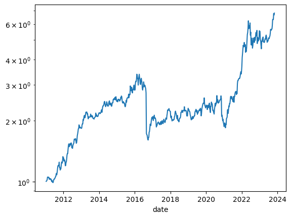

```python
(1+long_rets-short_rets).cumprod().plot(logy=True)
```

### What are the top 44 and bottom 44 today?

- Apply penny stock and size filters to today dataframe
- Rank on momentum (low rank = high momentum = best)
- Rank on value (low rank = low pb = best)
- Add ranks
- Find best 44 and worst 44 stocks today

```python
long
```

|  | ticker | sector | mom_rnk | pb_rnk | combined_rnk | closeunadj |
| --- | --- | --- | --- | --- | --- | --- |
| 772871 | EHTH | Financial Services | 26 | 32 | 58 | 7.860 |
| 427948 | CBUS | Healthcare | 30 | 69 | 99 | 10.270 |
| 2367118 | TRML | Healthcare | 78 | 53 | 131 | 14.000 |
| 1429651 | LSEA | Real Estate | 97 | 39 | 136 | 7.240 |
| 2197648 | SPHR | Communication Services | 100 | 51 | 151 | 33.470 |
| 387833 | BZH | Consumer Cyclical | 48 | 221 | 269 | 23.430 |
| 2449388 | USAP | Basic Materials | 102 | 197 | 299 | 14.020 |
| 1761051 | OPRT | Financial Services | 272 | 44 | 316 | 5.510 |
| 1597522 | MUX | Basic Materials | 99 | 267 | 366 | 7.090 |
| 1488461 | MDV | Real Estate | 125 | 260 | 385 | 15.210 |
| 1139786 | HOV | Consumer Cyclical | 29 | 362 | 391 | 66.360 |
| 1593141 | MTW | Industrials | 128 | 266 | 394 | 12.320 |
| 2200559 | SPNT | Financial Services | 129 | 294 | 423 | 9.610 |
| 950535 | FRD | Basic Materials | 276 | 147 | 423 | 9.710 |
| 1041933 | GNW | Financial Services | 392 | 33 | 425 | 5.810 |
| 2178802 | SNFCA | Financial Services | 325 | 103 | 428 | 7.050 |
| 1706041 | NWLI | Financial Services | 46 | 390 | 436 | 478.460 |
| 488571 | CION | Financial Services | 322 | 126 | 448 | 9.700 |
| 2149533 | SKYW | Industrials | 36 | 413 | 449 | 42.270 |
| 925188 | FLXS | Consumer Cyclical | 239 | 241 | 480 | 19.750 |
| 1013867 | GHLD | Financial Services | 406 | 80 | 486 | 10.650 |
| 1148943 | HRTG | Financial Services | 6 | 490 | 496 | 5.850 |
| 1763361 | OPY | Financial Services | 457 | 45 | 502 | 33.710 |
| 1738882 | OIS | Energy | 232 | 272 | 504 | 7.990 |
| 306996 | BH | Consumer Cyclical | 442 | 65 | 507 | 144.660 |
| 32796 | ACOR | Healthcare | 513 | 3 | 516 | 9.560 |
| 941111 | FOR | Real Estate | 41 | 480 | 521 | 23.390 |
| 438831 | CCS | Consumer Cyclical | 195 | 328 | 523 | 60.850 |
| 2300744 | TDS | Communication Services | 504 | 24 | 528 | 17.800 |
| 1309749 | KELYA | Industrials | 445 | 86 | 531 | 17.580 |
| 2639665 | ZIMV | Healthcare | 508 | 27 | 535 | 7.020 |
| 2097818 | SCX | Industrials | 356 | 194 | 550 | 10.390 |
| 1700409 | NVRI | Industrials | 162 | 389 | 551 | 5.730 |
| 429145 | CCAP | Financial Services | 227 | 327 | 554 | 15.445 |
| 1026237 | GLRE | Financial Services | 308 | 247 | 555 | 10.750 |
| 256238 | AXR | Real Estate | 243 | 313 | 556 | 16.700 |
| 574003 | CPSS | Financial Services | 225 | 332 | 557 | 9.390 |
| 1297858 | JXN | Financial Services | 525 | 38 | 563 | 37.190 |
| 1515142 | MHO | Consumer Cyclical | 68 | 502 | 570 | 81.320 |
| 988986 | GBLI | Financial Services | 220 | 353 | 573 | 36.480 |
| 2354021 | TPH | Consumer Cyclical | 152 | 423 | 575 | 24.440 |
| 1157233 | HT | Real Estate | 426 | 157 | 583 | 9.890 |
| 2503950 | VRA | Consumer Cyclical | 57 | 536 | 593 | 7.190 |
| 286492 | BCSF | Financial Services | 286 | 317 | 603 | 14.690 |

```python
short
```

|  | ticker | sector | mom_rnk | pb_rnk | combined_rnk | closeunadj |
| --- | --- | --- | --- | --- | --- | --- |
| 291701 | BE | Industrials | 1409 | 1654 | 3063 | 9.780 |
| 1903132 | PRCT | Healthcare | 1393 | 1678 | 3071 | 26.090 |
| 260770 | AYX | Technology | 1304 | 1767 | 3071 | 31.460 |
| 244448 | AVXL | Healthcare | 1685 | 1399 | 3084 | 5.200 |
| 1447625 | LYFT | Technology | 1387 | 1701 | 3088 | 9.260 |
| 1217100 | IMXI | Technology | 1566 | 1524 | 3090 | 16.200 |
| 1253736 | IRTC | Healthcare | 1378 | 1716 | 3094 | 78.190 |
| 2107199 | SEMR | Technology | 1463 | 1635 | 3098 | 8.050 |
| 2418352 | UDMY | Consumer Defensive | 1551 | 1551 | 3102 | 8.770 |
| 2375532 | TRUP | Financial Services | 1665 | 1438 | 3103 | 20.690 |
| 804166 | ENVX | Industrials | 1494 | 1628 | 3122 | 8.770 |
| 1569788 | MRTX | Healthcare | 1557 | 1579 | 3136 | 55.370 |
| 2630788 | YOU | Technology | 1433 | 1704 | 3137 | 16.520 |
| 1298662 | JYNT | Healthcare | 1690 | 1471 | 3161 | 7.890 |
| 2227119 | SSTI | Technology | 1722 | 1449 | 3171 | 14.790 |
| 2339832 | TMCI | Healthcare | 1678 | 1539 | 3217 | 9.500 |
| 220283 | ATOM | Technology | 1560 | 1665 | 3225 | 6.320 |
| 2388282 | TTGT | Communication Services | 1732 | 1497 | 3229 | 25.260 |
| 2298608 | TCX | Technology | 1734 | 1496 | 3230 | 16.690 |
| 1374556 | LEE | Consumer Cyclical | 1658 | 1578 | 3236 | 8.960 |
| 350200 | BOWL | Consumer Cyclical | 1518 | 1718 | 3236 | 10.340 |
| 2524170 | VVI | Industrials | 1484 | 1759 | 3243 | 23.050 |
| 1549618 | MODN | Technology | 1552 | 1692 | 3244 | 23.770 |
| 1550287 | MODV | Healthcare | 1769 | 1493 | 3262 | 40.130 |
| 1694815 | NVCR | Healthcare | 1777 | 1487 | 3264 | 12.640 |
| 312569 | BIGC | Technology | 1513 | 1754 | 3267 | 8.925 |
| 2345995 | TNDM | Healthcare | 1759 | 1508 | 3267 | 17.990 |
| 356528 | BRDG | Financial Services | 1565 | 1706 | 3271 | 7.120 |
| 794073 | ENFN | Technology | 1524 | 1750 | 3274 | 8.250 |
| 2229642 | STAA | Healthcare | 1660 | 1619 | 3279 | 38.550 |
| 1544665 | MNTK | Utilities | 1657 | 1644 | 3301 | 9.750 |
| 1011292 | GH | Healthcare | 1592 | 1710 | 3302 | 24.960 |
| 507828 | CLPT | Healthcare | 1715 | 1589 | 3304 | 5.180 |
| 806691 | EP | Energy | 1618 | 1707 | 3325 | 8.020 |
| 97708 | ALHC | Healthcare | 1686 | 1640 | 3326 | 6.840 |
| 2395412 | TVTX | Healthcare | 1750 | 1577 | 3327 | 6.800 |
| 2077665 | SAVA | Healthcare | 1736 | 1593 | 3329 | 19.890 |
| 2514031 | VSCO | Consumer Cyclical | 1741 | 1611 | 3352 | 18.520 |
| 1458847 | MARPS | Energy | 1662 | 1713 | 3375 | 5.030 |
| 1056027 | GRND | Technology | 1674 | 1769 | 3443 | 5.870 |
| 2379344 | TSE | Basic Materials | 1735 | 1708 | 3443 | 5.990 |
| 38102 | ACXP | Healthcare | 1733 | 1719 | 3452 | 5.380 |
| 2056469 | RVNC | Healthcare | 1697 | 1756 | 3453 | 7.980 |
| 1856242 | PI | Technology | 1724 | 1768 | 3492 | 61.660 |

### Sector weights

```python
long.groupby("sector").ticker.count()
```

```
sector
Basic Materials            3
Communication Services     2
Consumer Cyclical          8
Energy                     1
Financial Services        16
Healthcare                 4
Industrials                5
Real Estate                5
Name: ticker, dtype: int64
```

```python
short.groupby("sector").ticker.count()
```

```
sector
Basic Materials            1
Communication Services     1
Consumer Cyclical          3
Consumer Defensive         1
Energy                     2
Financial Services         2
Healthcare                17
Industrials                3
Technology                13
Utilities                  1
Name: ticker, dtype: int64
```

### Value and Momentum Portfolios III

- Rank on combined rank separately in each sector
- Do that by grouping by date and sector instead of just date
- Go long best 4 and short worst 4 in each sector to get sector neutrality
- Compute equally weighted returns for long and short portfolios
- Compute long minus short return

```python
print(f"annualized mean long return is {52*long_rets.mean():.2%}")
print(f"annualized mean short return is {52*short_rets.mean():.2%}")
```

```
annualized mean long return is 15.32%
annualized mean short return is 1.54%
```

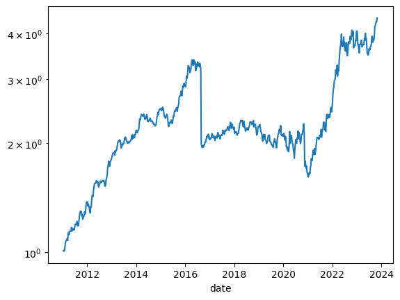

```python
(1+long_rets-short_rets).cumprod().plot(logy=True)
```

### Best and worst stocks today in sector-neutral strategy

- Just group by sector when ranking
- Choose best 4 and worst 4 in each sector

```python
long_neutral
```

|  | ticker | sector | mom_rnk | pb_rnk | combined_rnk | closeunadj |
| --- | --- | --- | --- | --- | --- | --- |
| 2449388 | USAP | Basic Materials | 102 | 197 | 299 | 14.020 |
| 1597522 | MUX | Basic Materials | 99 | 267 | 366 | 7.090 |
| 950535 | FRD | Basic Materials | 276 | 147 | 423 | 9.710 |
| 2638060 | ZEUS | Basic Materials | 47 | 636 | 683 | 49.430 |
| 2197648 | SPHR | Communication Services | 100 | 51 | 151 | 33.470 |
| 2300744 | TDS | Communication Services | 504 | 24 | 528 | 17.800 |
| 2455127 | USM | Communication Services | 274 | 430 | 704 | 41.390 |
| 1177442 | IAC | Communication Services | 704 | 159 | 863 | 41.840 |
| 387833 | BZH | Consumer Cyclical | 48 | 221 | 269 | 23.430 |
| 1139786 | HOV | Consumer Cyclical | 29 | 362 | 391 | 66.360 |
| 925188 | FLXS | Consumer Cyclical | 239 | 241 | 480 | 19.750 |
| 306996 | BH | Consumer Cyclical | 442 | 65 | 507 | 144.660 |
| 2193812 | SPB | Consumer Defensive | 106 | 620 | 726 | 75.250 |
| 889276 | FDP | Consumer Defensive | 727 | 140 | 867 | 25.010 |
| 2601835 | WVVI | Consumer Defensive | 856 | 59 | 915 | 5.242 |
| 142373 | ANDE | Consumer Defensive | 197 | 854 | 1051 | 49.310 |
| 1738882 | OIS | Energy | 232 | 272 | 504 | 7.990 |
| 1123116 | HLX | Energy | 116 | 584 | 700 | 9.870 |
| 1641108 | NGS | Energy | 315 | 385 | 700 | 14.220 |
| 538462 | CNX | Energy | 268 | 458 | 726 | 21.200 |
| 772871 | EHTH | Financial Services | 26 | 32 | 58 | 7.860 |
| 1761051 | OPRT | Financial Services | 272 | 44 | 316 | 5.510 |
| 2200559 | SPNT | Financial Services | 129 | 294 | 423 | 9.610 |
| 1041933 | GNW | Financial Services | 392 | 33 | 425 | 5.810 |
| 427948 | CBUS | Healthcare | 30 | 69 | 99 | 10.270 |
| 2367118 | TRML | Healthcare | 78 | 53 | 131 | 14.000 |
| 32796 | ACOR | Healthcare | 513 | 3 | 516 | 9.560 |
| 2639665 | ZIMV | Healthcare | 508 | 27 | 535 | 7.020 |
| 1593141 | MTW | Industrials | 128 | 266 | 394 | 12.320 |
| 2149533 | SKYW | Industrials | 36 | 413 | 449 | 42.270 |
| 1309749 | KELYA | Industrials | 445 | 86 | 531 | 17.580 |
| 2097818 | SCX | Industrials | 356 | 194 | 550 | 10.390 |
| 1429651 | LSEA | Real Estate | 97 | 39 | 136 | 7.240 |
| 1488461 | MDV | Real Estate | 125 | 260 | 385 | 15.210 |
| 941111 | FOR | Real Estate | 41 | 480 | 521 | 23.390 |
| 256238 | AXR | Real Estate | 243 | 313 | 556 | 16.700 |
| 2038182 | RPAY | Technology | 413 | 286 | 699 | 5.890 |
| 29775 | ACMR | Technology | 21 | 724 | 745 | 13.710 |
| 3791 | AAOI | Technology | 10 | 850 | 860 | 7.040 |
| 2373620 | TRT | Technology | 250 | 630 | 880 | 6.870 |
| 1035432 | GNE | Utilities | 167 | 1310 | 1477 | 19.180 |
| 94400 | ALE | Utilities | 838 | 642 | 1480 | 52.590 |
| 644205 | CWCO | Utilities | 124 | 1359 | 1483 | 29.030 |
| 1703602 | NWE | Utilities | 903 | 604 | 1507 | 46.550 |

```python
short_neutral
```

|  | ticker | sector | mom_rnk | pb_rnk | combined_rnk | closeunadj |
| --- | --- | --- | --- | --- | --- | --- |
| 1573351 | MSB | Basic Materials | 950 | 1725 | 2675 | 20.170 |
| 2165284 | SMID | Basic Materials | 1242 | 1447 | 2689 | 19.366 |
| 1555752 | MP | Basic Materials | 1572 | 1207 | 2779 | 16.500 |
| 2379344 | TSE | Basic Materials | 1735 | 1708 | 3443 | 5.990 |
| 1755960 | OOMA | Communication Services | 1203 | 1535 | 2738 | 10.740 |
| 934187 | FNGR | Communication Services | 1019 | 1749 | 2768 | 5.650 |
| 1042555 | GOGO | Communication Services | 1113 | 1776 | 2889 | 10.650 |
| 2388282 | TTGT | Communication Services | 1732 | 1497 | 3229 | 25.260 |
| 1492207 | MED | Consumer Cyclical | 1480 | 1561 | 3041 | 69.580 |
| 350200 | BOWL | Consumer Cyclical | 1518 | 1718 | 3236 | 10.340 |
| 1374556 | LEE | Consumer Cyclical | 1658 | 1578 | 3236 | 8.960 |
| 2514031 | VSCO | Consumer Cyclical | 1741 | 1611 | 3352 | 18.520 |
| 2359074 | TR | Consumer Defensive | 1293 | 1381 | 2674 | 30.300 |
| 1836328 | PETS | Consumer Defensive | 1700 | 1048 | 2748 | 9.360 |
| 2425203 | UG | Consumer Defensive | 1664 | 1382 | 3046 | 6.180 |
| 2418352 | UDMY | Consumer Defensive | 1551 | 1551 | 3102 | 8.770 |
| 1617424 | NBR | Energy | 1388 | 1389 | 2777 | 102.830 |
| 362958 | BROG | Energy | 1510 | 1529 | 3039 | 5.125 |
| 806691 | EP | Energy | 1618 | 1707 | 3325 | 8.020 |
| 1458847 | MARPS | Energy | 1662 | 1713 | 3375 | 5.030 |
| 2468353 | VALU | Financial Services | 1414 | 1568 | 2982 | 34.500 |
| 1869626 | PLMR | Financial Services | 1625 | 1433 | 3058 | 49.360 |
| 2375532 | TRUP | Financial Services | 1665 | 1438 | 3103 | 20.690 |
| 356528 | BRDG | Financial Services | 1565 | 1706 | 3271 | 7.120 |
| 2395412 | TVTX | Healthcare | 1750 | 1577 | 3327 | 6.800 |
| 2077665 | SAVA | Healthcare | 1736 | 1593 | 3329 | 19.890 |
| 38102 | ACXP | Healthcare | 1733 | 1719 | 3452 | 5.380 |
| 2056469 | RVNC | Healthcare | 1697 | 1756 | 3453 | 7.980 |
| 845359 | EVEX | Industrials | 1261 | 1690 | 2951 | 7.480 |
| 291701 | BE | Industrials | 1409 | 1654 | 3063 | 9.780 |
| 804166 | ENVX | Industrials | 1494 | 1628 | 3122 | 8.770 |
| 2524170 | VVI | Industrials | 1484 | 1759 | 3243 | 23.050 |
| 2428020 | UHT | Real Estate | 1050 | 1297 | 2347 | 38.040 |
| 113290 | ALX | Real Estate | 1102 | 1477 | 2579 | 179.250 |
| 1043620 | GOOD | Real Estate | 1328 | 1311 | 2639 | 11.640 |
| 1781891 | OUT | Real Estate | 1610 | 1208 | 2818 | 9.620 |
| 312569 | BIGC | Technology | 1513 | 1754 | 3267 | 8.925 |
| 794073 | ENFN | Technology | 1524 | 1750 | 3274 | 8.250 |
| 1056027 | GRND | Technology | 1674 | 1769 | 3443 | 5.870 |
| 1856242 | PI | Technology | 1724 | 1768 | 3492 | 61.660 |
| 1575731 | MSEX | Utilities | 1264 | 1371 | 2635 | 63.500 |
| 1076808 | GWRS | Utilities | 1130 | 1605 | 2735 | 9.970 |
| 757849 | EE | Utilities | 1547 | 1466 | 3013 | 15.060 |
| 1544665 | MNTK | Utilities | 1657 | 1644 | 3301 | 9.750 |

```python
long_neutral.groupby("sector").ticker.count()
```

```
sector
Basic Materials           4
Communication Services    4
Consumer Cyclical         4
Consumer Defensive        4
Energy                    4
Financial Services        4
Healthcare                4
Industrials               4
Real Estate               4
Technology                4
Utilities                 4
Name: ticker, dtype: int64
```

```python
short_neutral.groupby("sector").ticker.count()
```

```
sector
Basic Materials           4
Communication Services    4
Consumer Cyclical         4
Consumer Defensive        4
Energy                    4
Financial Services        4
Healthcare                4
Industrials               4
Real Estate               4
Technology                4
Utilities                 4
Name: ticker, dtype: int64
```

### How many shares to buy/sell?

- Can do this either for long and short or long_neutral and short_neutral
- $1,000,000 to invest long and short
- Divide by number of stocks to get $ per stock
- Divide by price to get shares per stock

### Long side

```python
long_neutral["shares"] = (1000000/long_neutral.shape[0])/long_neutral.closeunadj
long_neutral["shares"] = long_neutral.shares.round(0).astype(int)

long["shares"] = (1000000/long.shape[0])/long.closeunadj
long["shares"] = long.shares.round(0).astype(int)
```

### Short side

```python
short_neutral["shares"] = (1000000/short_neutral.shape[0])/short_neutral.closeunadj
short_neutral["shares"] = short_neutral.shares.round(0).astype(int)

short["shares"] = (1000000/short.shape[0])/short.closeunadj
short["shares"] = short.shares.round(0).astype(int)
```

```python
with pd.ExcelWriter("portfolios 2023-11-02.xlsx") as writer:
    long.to_excel(writer, "long", index=False)
    short.to_excel(writer, "short", index=False)
    long_neutral.to_excel(writer, "long neutral", index=False)
    short_neutral.to_excel(writer, "short neutral", index=False)
    today.to_excel(writer, "today", index=False)
```